# Graphical data exploration

Michael France Nelson

February, 2020

# 1 Overview

In this activity, you’ll be building you skills with graphical exploration of data in R.

You’ll need to use several functions that we haven’t talked about in class to complete this activity.

You’ll also need some new arguments to modify the look of scatterplots.

# 2 Subsetting data frames

Often you want to use only a *subset* of observations contained in a dataframe.

To accomplish this, you need to decide what criteria you want to use to select those observations you wish to keep.

One way to do this is by using *logical subsetting*.

You’ve read about logical tests in the swirl tutorials, and now you’ll have a chance to practice with some real data.

## 2.1 Subsetting examples

In the following examples, I’ll use one of R’s built-in data sets: `mtcars`.

To load the data into R’s memory you need to type: `data(mtcars)`

To familiarize yourself with the data, use `head()` to view the first six rows:

```r
data(mtcars)
head(mtcars)
```

```
##                    mpg cyl disp  hp drat    wt  qsec vs am gear carb
## Mazda RX4         21.0   6  160 110 3.90 2.620 16.46  0  1    4    4
## Mazda RX4 Wag     21.0   6  160 110 3.90 2.875 17.02  0  1    4    4
## Datsun 710        22.8   4  108  93 3.85 2.320 18.61  1  1    4    1
## Hornet 4 Drive    21.4   6  258 110 3.08 3.215 19.44  1  0    3    1
## Hornet Sportabout 18.7   8  360 175 3.15 3.440 17.02  0  0    3    2
## Valiant           18.1   6  225 105 2.76 3.460 20.22  1  0    3    1
```

The column called “hp” shows the horsepower of each car in the data set:

```r
mtcars$hp
```

```
##  [1] 110 110  93 110 175 105 245  62  95 123 123 180 180 180 205 215 230  66  52
## [20]  65  97 150 150 245 175  66  91 113 264 175 335 109
```

How can you retrieve the data for cars that have less than 75 horsepower?

You can use a logical test to show which entries in the `hp` column are less than 75:

```r
mtcars$hp < 75
```

```
##  [1] FALSE FALSE FALSE FALSE FALSE FALSE FALSE  TRUE FALSE FALSE FALSE FALSE
## [13] FALSE FALSE FALSE FALSE FALSE  TRUE  TRUE  TRUE FALSE FALSE FALSE FALSE
## [25] FALSE  TRUE FALSE FALSE FALSE FALSE FALSE FALSE
```

How can we use this info to pull out the low horsepower cars?

Use the `subset()` function. It allows us to keep only the rows of the data frame that match our criteria.

Here’s how I would retrieve the low horsepower cars:

```r
subset(mtcars, hp < 75)
```

```
##                 mpg cyl  disp hp drat    wt  qsec vs am gear carb
## Merc 240D      24.4   4 146.7 62 3.69 3.190 20.00  1  0    4    2
## Fiat 128       32.4   4  78.7 66 4.08 2.200 19.47  1  1    4    1
## Honda Civic    30.4   4  75.7 52 4.93 1.615 18.52  1  1    4    2
## Toyota Corolla 33.9   4  71.1 65 4.22 1.835 19.90  1  1    4    1
## Fiat X1-9      27.3   4  79.0 66 4.08 1.935 18.90  1  1    4    1
```

How would you select the cars that have exactly 110 horsepower?

```r
subset(mtcars, hp == 110)
```

```
##                 mpg cyl disp  hp drat    wt  qsec vs am gear carb
## Mazda RX4      21.0   6  160 110 3.90 2.620 16.46  0  1    4    4
## Mazda RX4 Wag  21.0   6  160 110 3.90 2.875 17.02  0  1    4    4
## Hornet 4 Drive 21.4   6  258 110 3.08 3.215 19.44  1  0    3    1
```

Note the double equals sign: `==`

The main logical operators in R include:

`==`

`>`

`<`

`>=`

`<=`

# 3 Rarefaction data plots

For this activity, we’re going to use the rarefaction data that we collected on the first day of class.

You’ll need to download the data file `rarefaction_data_2020.csv` from Moodle and load it into R.

The data should look like this:

```
##   X site sample n_species n_individuals
## 1 1    1      1        21           101
## 2 2    1      1        21           101
## 3 3    1      1        20           104
## 4 4    1      1        20           104
## 5 5    1      1        18           100
## 6 6    1      1        18           100
```

You’ll need to create 5 scatterplots. All of your scatterplots need to have the number of individuals on the x-axis and the number of distinct species on the y axis.

- **Scatterplot 1**: A plot of all samples
- **Scatterplot 2**: A plot of all samples from site 1
- **Scatterplot 3**: A plot of all samples from site 2
- **Scatterplot 4**: A plot of all samples from site 3
- **Scatterplot 5**: A plot of all samples from site 4

You’ll need to use teh `subset()` function to retrieve the data rows for indivial study sites (sites 1 - 4). Follow the example with `mtcars` above.

## 3.1 Scatterplot parameters

When you plot the subsets of the rarefaction data, you might notice that the x-axis doesn’t always start at 0. You’ll need to use the `xlim` argument within `plot()` to specify the minimum and maximum values shown in the plot window.

For example, here are two plots of dat from site #4. The first plot uses the default x limits, the second plot specifies that the x-axis should range from 0 to 90

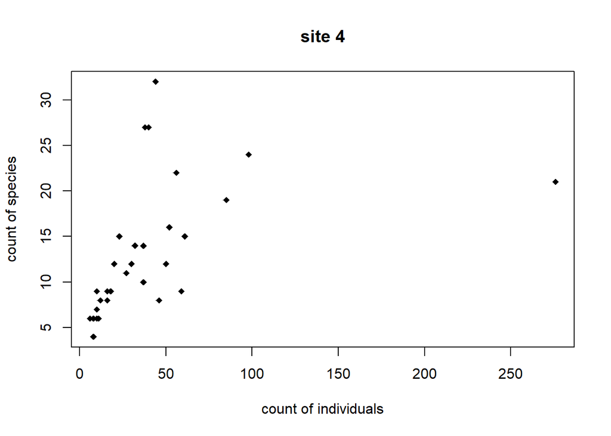

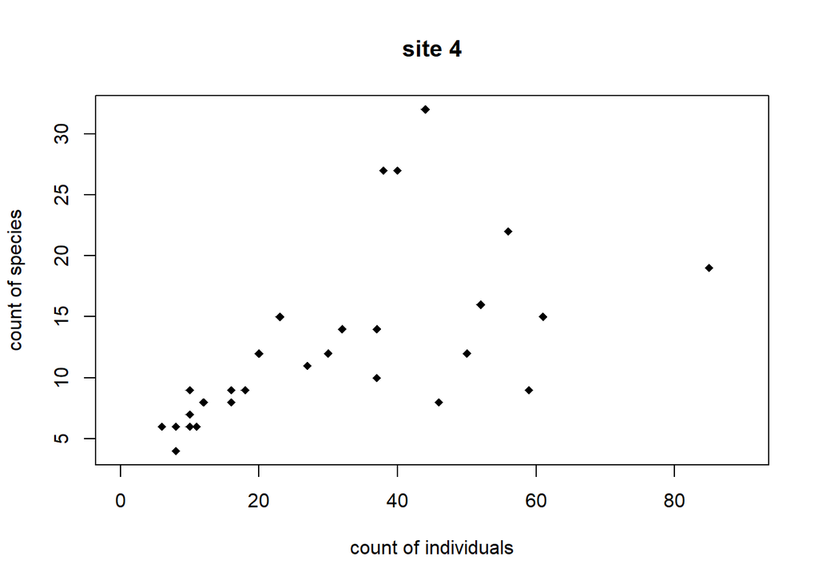

Note: The second plot omits two of the data points!

# 4 Exercises

You’ll need to create the 5 scatterplots described above: 1 scatterplot that contains all fo the data, and four scatterplots that show the data for the four individual sites.

Each scatterplot must:

- Have appropriate title, x-axis label, and y-axis label.
- The x-axis range must include 0 in each plot. You need to choose an appropriate upper limit that includes all of the data points. You’ll probably need to try multiple values.
- The y-axis in every plot needs to range from 0 to 32

Each scatterplot is worth 8 points, there are 40 total points available for this exercise.

Your group will paste the 5 scatterplots into a document and upload it to Moodle.